# DSDA 1995

Data Science and Society using R

Lecture 16 | Geospatial Data II

## Plan for Today

- Explore plotting geolocated data in R

## `tmap`

- Recall, `tmap` is based on the idea of a ‘grammar of graphics’ similar to `ggplot`
  - This involves a separation between the input data and the aesthetics (how data are visualized): each input dataset can be ‘mapped’ in a range of different ways including location on the map (defined by data’s geometry), color, and other visual variables
- `tm_shape()`
  - defines the data, raster, and vector objects
- `tm_fill()` & `tm_borders()`
  - Control the layers that are added to represent `nz` visually

## `tmap`

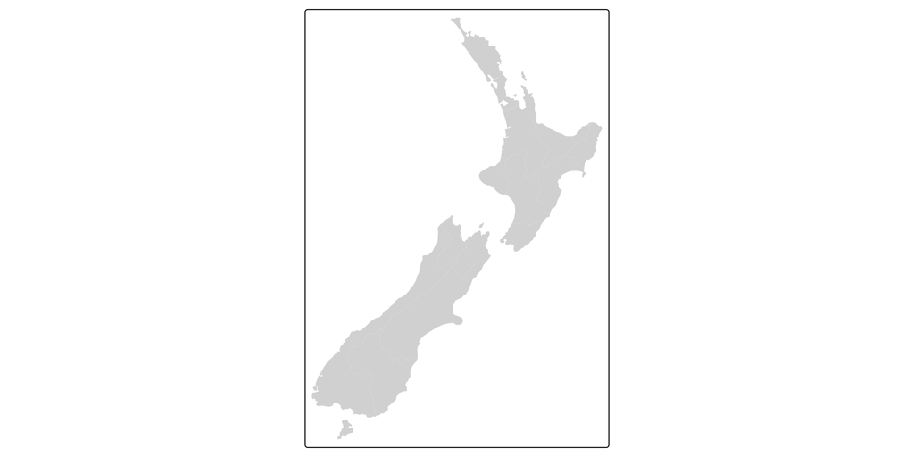

```r
#
#install.packages("spData")
library(spData)
library(tmap)

# Add fill layer to nz shape
tm_shape(nz) +
  tm_fill()
```

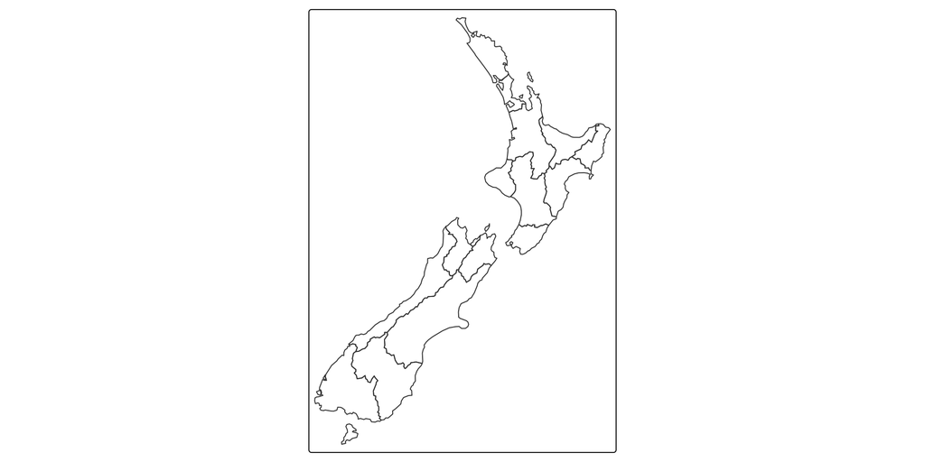

```r
# Add border layer to nz shape
tm_shape(nz) +
  tm_borders()
```

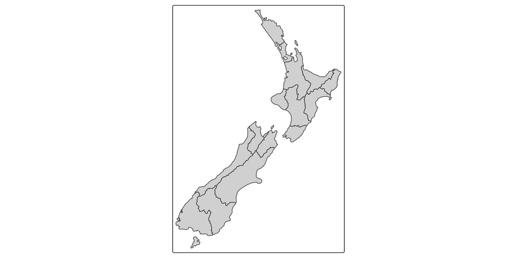

```r
# Add fill and border layers to nz shape
tm_shape(nz) +
  tm_fill() +
  tm_borders()
```

## `tmap`

- A useful feature of `tmap` is its ability to store objects representing maps

```r
map_nz = tm_shape(nz) + tm_polygons()

class(map_nz)
```

```
[1] "tmap"
```

- This allows you to plot your maps later and/or add additional layers

```r
map_nz1 = map_nz +
  tm_shape(elev) + tm_raster(alpha = 0.7)

map_nz1
```

[output not shown]

## `tmap`

- There are no limits to the number of layers or shapes that can be added to `tmap` objects
- Additionally, `tmap` allows multiple map objects to be arranged in a single plot with `tmap_arrange()`

```r
#map 2
nz_water = st_union(nz) |> st_buffer(22200) |>
  st_cast(to = "LINESTRING")
map_nz2 = map_nz1 +
  tm_shape(nz_water) + tm_lines()

#map 3
map_nz3 = map_nz2 +
  tm_shape(nz_height) + tm_dots()

#combined
tmap_arrange(map_nz1, map_nz2, map_nz3)
```

[output not shown]

## Aesthetics

- There are two main types of map aesthetics: those that change with the data and those that are constant

[figure not shown]

```r
ma1 = tm_shape(nz) + tm_fill(col = "red")

ma2 = tm_shape(nz) + tm_fill(col = "red", alpha = 0.3)

ma3 = tm_shape(nz) + tm_borders(col = "blue")

ma4 = tm_shape(nz) + tm_borders(lwd = 3)

ma5 = tm_shape(nz) + tm_borders(lty = 2)

ma6 = tm_shape(nz) + tm_fill(col = "red", alpha = 0.3) +
  tm_borders(col = "blue", lwd = 3, lty = 2)

tmap_arrange(ma1, ma2, ma3, ma4, ma5, ma6)
```

## Color Settings

- Color settings are an important part of map design. They can have a major impact on how spatial variability is portrayed

[figure not shown]

```r
tm_shape(nz) + tm_polygons(col = "Median_income")
```

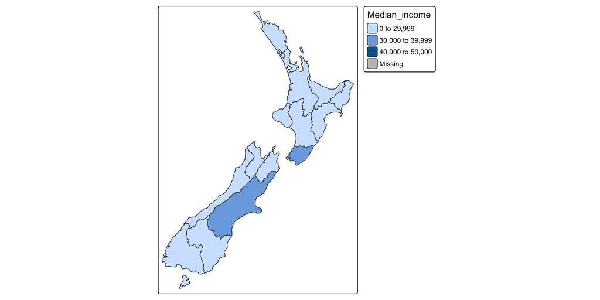

```r
breaks = c(0, 3, 4, 5) * 10000

tm_shape(nz) + tm_polygons(col = "Median_income", breaks = breaks)
```

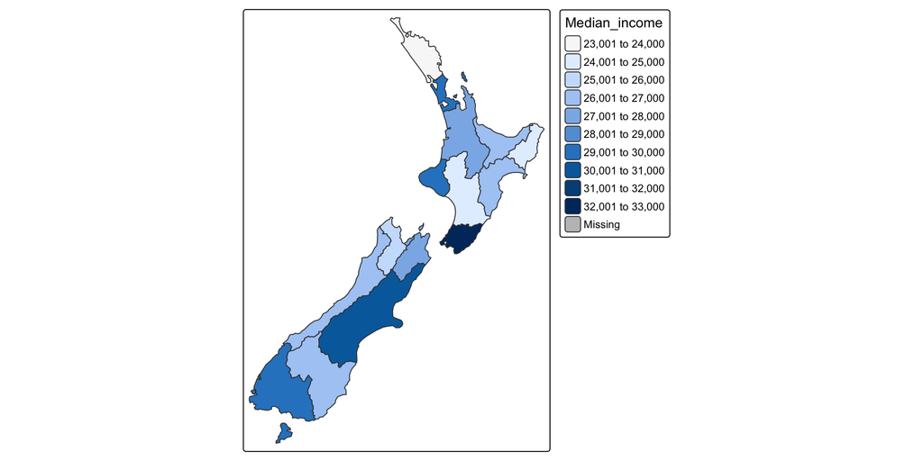

```r
tm_shape(nz) + tm_polygons(col = "Median_income", n = 10)
```

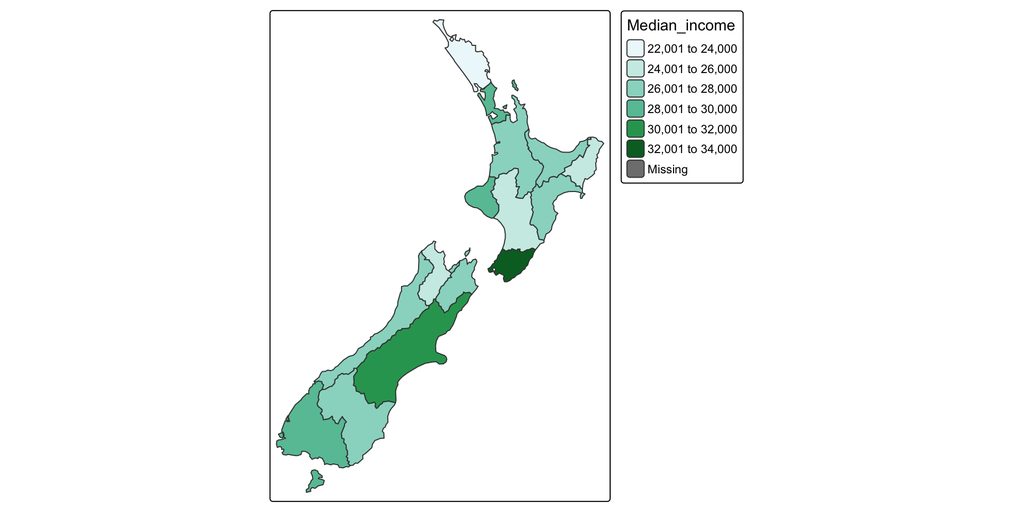

```r
tm_shape(nz) + tm_polygons(col = "Median_income", palette = "BuGn")
```

## Faceted Maps

- Faceted maps, also referred to as ‘small multiples,’ are composed of many maps arranged side-by-side

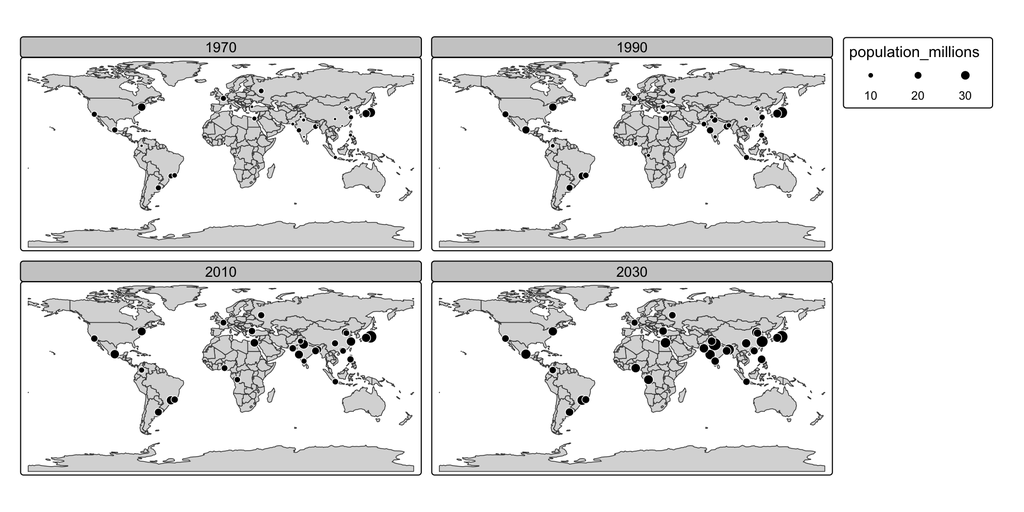

```r
urb_1970_2030 <- urban_agglomerations |>
  filter(year == 1970| year == 1990 | year == 2010 | year == 2030)


tm_shape(world) +
  tm_polygons() +
  tm_shape(urb_1970_2030) +
  tm_symbols(col = "black", border.col = "white", size = "population_millions") +
  tm_facets(by = "year", nrow = 2, free.coords = FALSE)
```

## Animated Maps

```r
urb_anim = tm_shape(world) + tm_polygons() +
  tm_shape(urban_agglomerations) + tm_dots(size = "population_millions") +
  tm_facets(along = "year", free.coords = FALSE)
```

## Animated Maps

- The resulting `urb_anim` represents a set of separate maps for each year
- The final stage is to combine them and save the result as a `.gif` file with `tmap_animation()`

```r
#install.packages("gifski")
library(gifski)

tmap_animation(urb_anim, filename = "urb_anim.gif", delay = 25)
```

```
Creating frames
```

```
Creating animation
Animation saved to /Users/jsb22018/Dropbox/Schools/UCONN/Courses/Spring 2025/DSDA 1995/Week 11/Lecture 1/urb_anim.gif
```

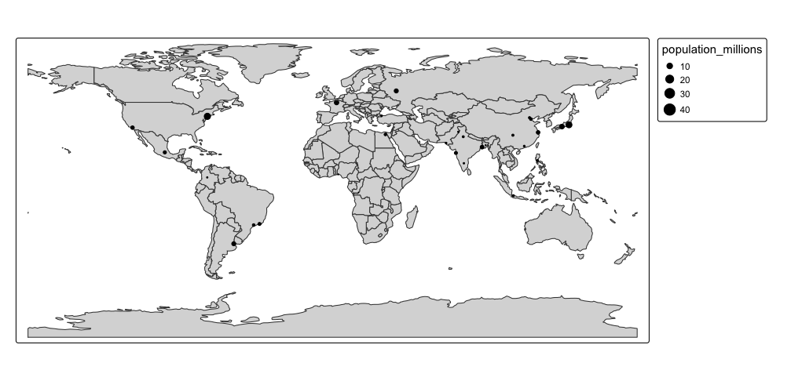

## Interactive Maps

- Interactivity can take many forms, the most common and useful of which is the ability to pan around and zoom into any part of a geographic dataset overlaid on a ‘web map’ to show context
- A unique feature of `tmap` is its ability to create static and interactive maps using the same code

```r
tmap_mode("view")
map_nz
```

[interactive chart not shown]

- Now that the interactive mode has been ‘turned on,’ all maps produced with `tmap` will launch (another way to create interactive maps is with the `tmap_leaflet function`)

```r
map_nz + tm_basemap(server = "OpenTopoMap")
```

[interactive chart not shown]

## Interactive Maps

- An impressive and little-known feature of tmap’s view mode is that it also works with faceted plots

```r
world_coffee = left_join(world, coffee_data, by = "name_long")
facets = c("coffee_production_2016", "coffee_production_2017")
tm_shape(world_coffee) + tm_polygons(facets) +
  tm_facets(nrow = 1, sync = TRUE)
```

[interactive chart not shown]

## Merging with Geometry and Data

- Every now and again you might need to merge a shape file (geometry) with a data frame
- You complete this in a very similar manner as joining two regular data frames
- We are going to use Census data from Mecklenberg County

```r
library(tidycensus)

meck_black <- get_decennial(geography = "tract",
                            variables = "P005004",
                            summary_var = "P001001",
                            state = "NC",
                            county = "Mecklenburg",
                            year=2010,
                            geometry = TRUE)

meck_white <- get_decennial(geography = "tract",
                            variables = "P005003",
                            summary_var = "P001001",
                            state = "NC",
                            county = "Mecklenburg",
                            year=2010,
                            geometry = FALSE)
```

## Merging with Geometry and Data

- We want to join the population of African American citizens with white citizens, by Census tract, in Mecklenburg county
- Let’s join them below

```r
meck_bw <- meck_black |>
  left_join(meck_white,
            by=c("GEOID", "NAME", "summary_value"),
            suffix = c("_black", "_white")) |>
  mutate(pct_white = value_white / summary_value,
         pct_black = value_black / summary_value)
```

- Let’s plot it

```r
meck_one <- meck_bw |>
  tm_shape() +
  tm_polygons("pct_white")

meck_one

meck_two <- meck_bw |>
  tm_shape() +
  tm_polygons("pct_black")

meck_two

tmap_arrange(meck_one, meck_two)
```

[output not shown]

## Plotting with `sf`

- Using shapefiles from the US Census
  - Shapefiles provide the geographic coordinates for a specific boundary
  - It’s essentially a set of related files that contain the spatial data (geometry), an index to that data, and attribute information about each feature.

```r
library(sf)

congdistricts <- st_read("districts116.shp") |>
  arrange(STATENAME, DISTRICT)
```

- We will filter the data to only include Connecticut and then plot the congressional districts

```r
ct <- congdistricts |>
  filter(STATENAME == "Connecticut")
```

## Plotting with `sf`

- We can use the `plot()` function

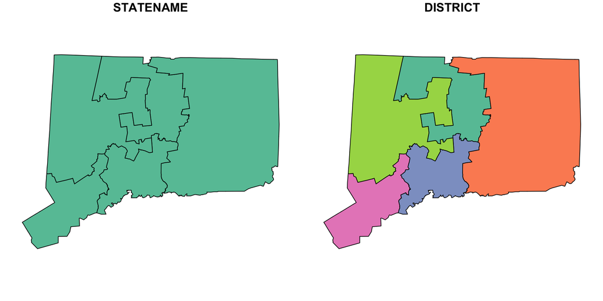

```r
plot(ct)
```

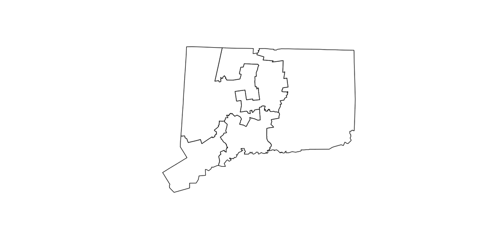

```r
#
plot(ct$geometry)
```

## Plotting with `sf`

- We can also use `ggplot()`

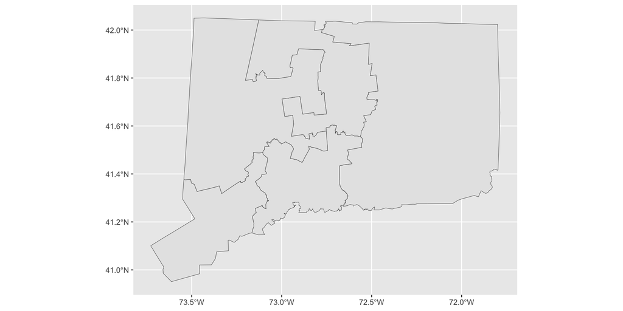

```r
ggplot() +
  geom_sf(data = ct)
```

- As is expected, the basic `ggplot()` call is not visually appealing

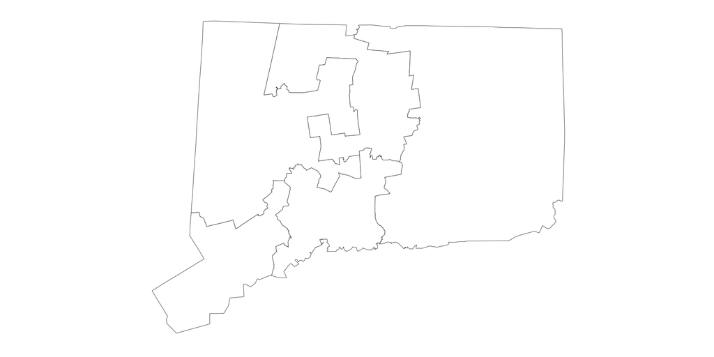

```r
ggplot() +
  geom_sf(data = ct$geometry, fill = "white") +
  theme_bw() +
  theme(panel.border = element_blank(),
        panel.grid.major = element_blank(),
        panel.grid.minor = element_blank(),
        axis.text.x = element_blank(),
        axis.ticks.x = element_blank(),
        axis.text.y = element_blank(),
        axis.ticks.y = element_blank(),
        plot.caption = element_text(hjust = 0.5))
```

## Raster Data

- Raster files, as you might know, have a much more compact data structure than vectors
- A raster is defined by:
  - a CRS
  - coordinates of its origin
  - a distance or cell size in each direction
  - a dimension or numbers of cells in each direction
  - an array of cell values

## Raster Data

- Let’s look at a population raster

```r
library(raster)

popraster <- raster("gpw_v4_population_count_rev11_2020_30_sec.tif")
```

- This raster presents population estimates for the entire world in 2020
- While we could try and plot this…
  - It would take a lot of computing power and not really reveal anything to us
  - Let’s extract the raster data for the area that we care about (i.e., the congressional districts of Connecticut)

## Raster Data

- Let’s create a raster file that is concentrated on Connecticut

```r
#create boundary for raster data for CT 2nd district
CTrasterdata <- mask(crop(popraster, extent(ct)), ct)
```

- Let’s plot the raster data

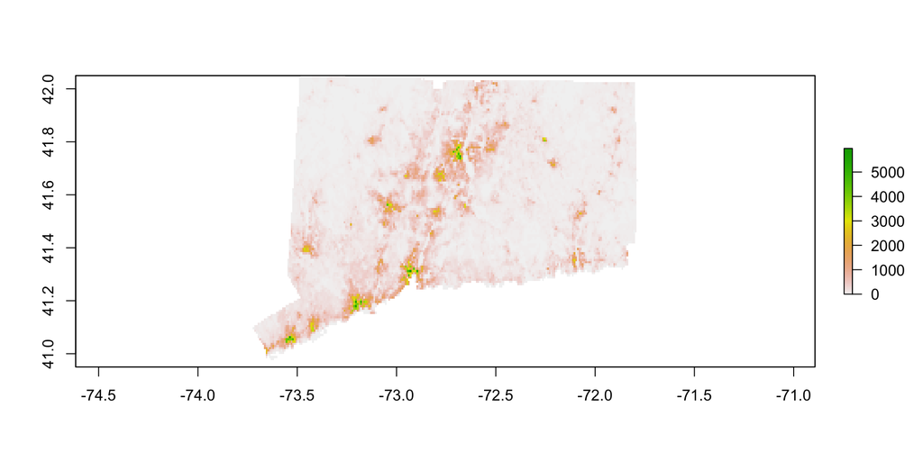

```r
plot(CTrasterdata)
```

## Raster Data

- Let’s plot with `ggplot()`

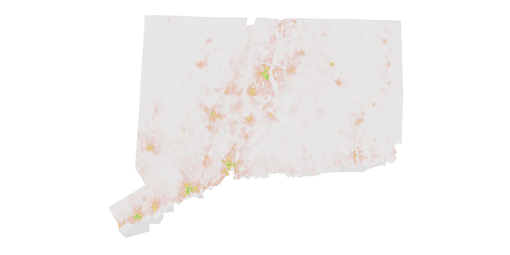

```r
#convert raster data to spatial points
trythis <- rasterToPoints(CTrasterdata) %>%
  data.frame() %>%
  rename(pop = gpw_v4_population_count_rev11_2020_30_sec)

#raster data
ggplot() +
  geom_sf(data = ct$geometry, colour = NA) +
  geom_raster(data = trythis, mapping = aes(x = x, y = y, fill = pop), alpha = 0.5) +
  scale_fill_gradientn(colours = rev(terrain.colors(10))) +
  theme_bw() +
  theme(panel.border = element_blank(),
        panel.grid.major = element_blank(),
        panel.grid.minor = element_blank(),
        axis.text.x = element_blank(),
        axis.title.x = element_blank(),
        axis.title.y = element_blank(),
        axis.ticks.x = element_blank(),
        axis.text.y = element_blank(),
        axis.ticks.y = element_blank(),
        legend.position="none",
        plot.caption = element_text(hjust = 0.5))
```

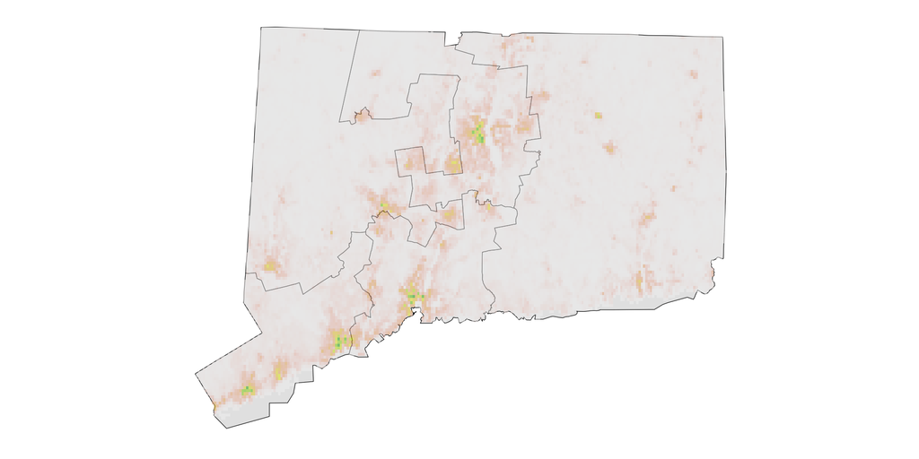

```r
#raster data with CDs
ggplot() +
  geom_sf(data = ct$geometry, colour = "black") +
  geom_raster(data = trythis, mapping = aes(x = x, y = y, fill = pop), alpha = 0.5) +
  scale_fill_gradientn(colours = rev(terrain.colors(10))) +
  theme_bw() +
  theme(panel.border = element_blank(),
        panel.grid.major = element_blank(),
        panel.grid.minor = element_blank(),
        axis.text.x = element_blank(),
        axis.title.x = element_blank(),
        axis.title.y = element_blank(),
        axis.ticks.x = element_blank(),
        axis.text.y = element_blank(),
        axis.ticks.y = element_blank(),
        legend.position="none",
        plot.caption = element_text(hjust = 0.5))
```

## Raster Data

- How can we use raster data?
- We can extract the estimates from the raster and use them

```r
library(exactextractr)

ct_pop_estimate <- round(exact_extract(CTrasterdata, ct, 'sum'), 3) %>%
          data.frame() %>%
          rename(popSUM = ".")
ct_pop_estimate
```

```
    popSUM
1 748919.2
2 766355.1
3 739518.4
4 740402.1
5 742843.2
```